# Trabalho de Probabilidade e Estatística

Brainer Sueverti de Campos - 790829 | Thiago Martins - 790964

20/04/2022

```r
  #install.packages("readr");
  #install.packages("ggplot2");
  #install.packages("dplyr");
  #install.packages("hrbrthemes");
  #install.packages("tidyverse");
  #library(readr)
  #library(ggplot2)
  #library(dplyr)
  #library(hrbrthemes)
  #library(tidyverse)
```

## As analises Univariadas forma feitas nas 5 variaveis (SalePrice, OverallQual, OverallCond,YearBuilt e GarageCars). Calculamos média, mediana,intervalo, distância interquartilica, variância, desvio padrão, tabela de frequência, boxplot, histograma e gráfico de densidade.

## OverrallQual (índice de qualidade geral)

## A variável OverallQuall está levemente à direita ao analisar o grafico de densidade, histograma e o boxplot. Analisando númericamente vemos que os valores a diretita na tabela de frequência estão maiores também.

```r
cat("Média: ", mean(overallqual),"\n")
```

```
## Média:  6.099315
```

```r
cat("Mediana:",median(overallqual),"\n")
```

```
## Mediana: 6
```

```r
cat("Intervalo:",max(overallqual) - min(overallqual),"\n")
```

```
## Intervalo: 9
```

```r
cat("Distancia Interquartilica:",IQR(overallqual),'\n')
```

```
## Distancia Interquartilica: 2
```

```r
cat('Variância:',var(overallqual),'\n')
```

```
## Variância: 1.912679
```

```r
cat('Desvio Padrão:',sd(overallqual),'\n')
```

```
## Desvio Padrão: 1.382997
```

```r
cat('\nTabela de Frequência')
```

```
##
## Tabela de Frequência
```

```r
table(overallqual)
```

```
## overallqual
##   1   2   3   4   5   6   7   8   9  10
##   2   3  20 116 397 374 319 168  43  18
```

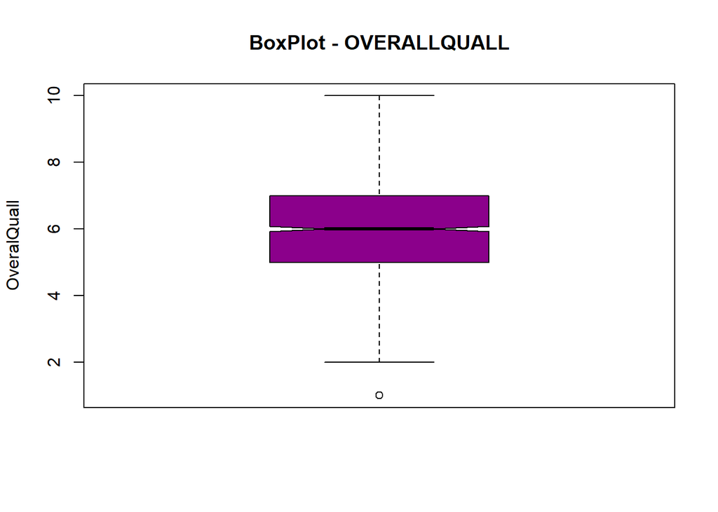

```r
boxplot(overallqual,
main = "BoxPlot - OVERALLQUALL",
ylab = "OveralQuall",
col = "#8b008b",
border = "black",
notch = TRUE
)
```

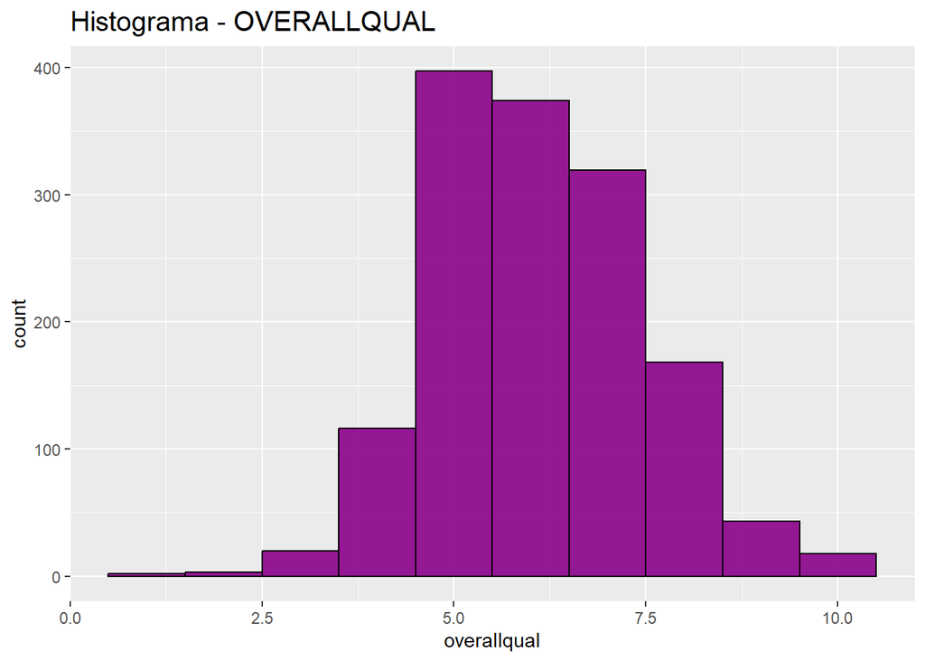

```r
p <- data %>%
  ggplot( aes(x=overallqual)) +
    geom_histogram( binwidth=1, fill="#8b008b", color="#000000", alpha=0.9) +
    ggtitle('Histograma - OVERALLQUAL') +
    theme(
      plot.title = element_text(size=15)
    )
p
```

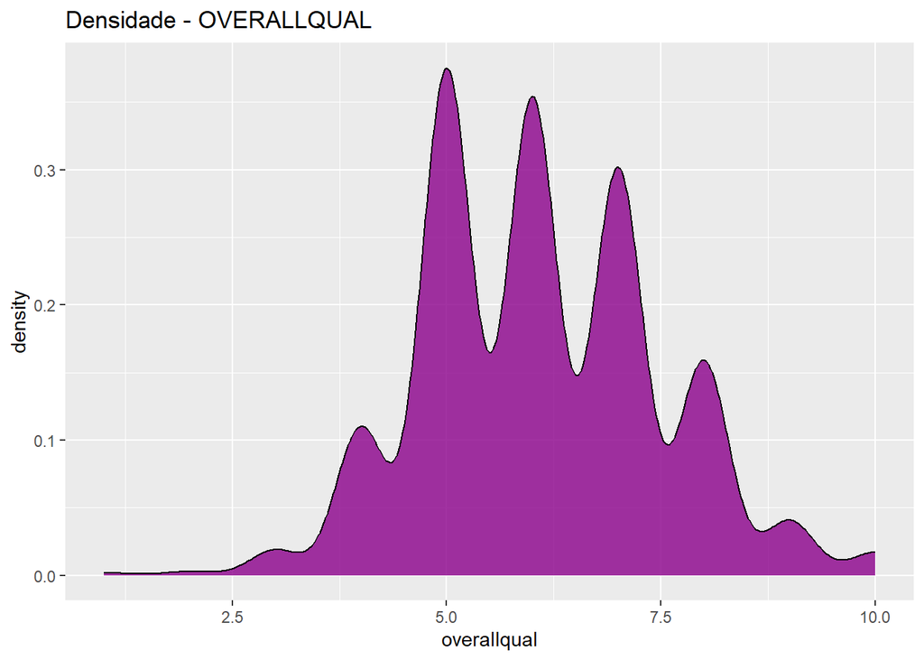

```r
data %>%
  ggplot( aes(x=overallqual)) +
    geom_density(fill="#8b008b", color="#000000", alpha=0.8) +
    ggtitle("Densidade - OVERALLQUAL")
```

## OverrallCond(índice do estado do imóvel)

## A variável OverralCond segue a mesma tendência da Variável OverralQual com um leve deslocamento à direita, indicado uma leve tendência a imóveis em bom estado.

```r
cat("Média: ", mean(overallcond),"\n")
```

```
## Média:  5.575342
```

```r
cat("Mediana:",median(overallcond),"\n")
```

```
## Mediana: 5
```

```r
cat("Intervalo:",max(overallcond) - min(overallcond),"\n")
```

```
## Intervalo: 8
```

```r
cat("Distancia Interquartilica:",IQR(overallcond),'\n')
```

```
## Distancia Interquartilica: 1
```

```r
cat('Variância:',var(overallcond),'\n')
```

```
## Variância: 1.238322
```

```r
cat('Desvio Padrão:',sd(overallcond),'\n')
```

```
## Desvio Padrão: 1.112799
```

```r
cat('\nTabela de Frequência')
```

```
##
## Tabela de Frequência
```

```r
table(overallcond)
```

```
## overallcond
##   1   2   3   4   5   6   7   8   9
##   1   5  25  57 821 252 205  72  22
```

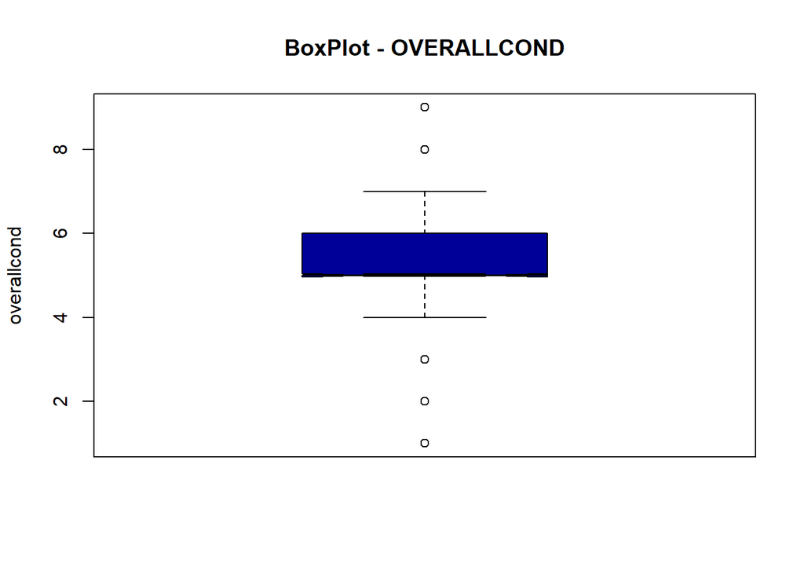

```r
boxplot(overallcond,
main = "BoxPlot - OVERALLCOND",
ylab = "overallcond",
col = "#000099",
border = "black",
notch = TRUE
)
```

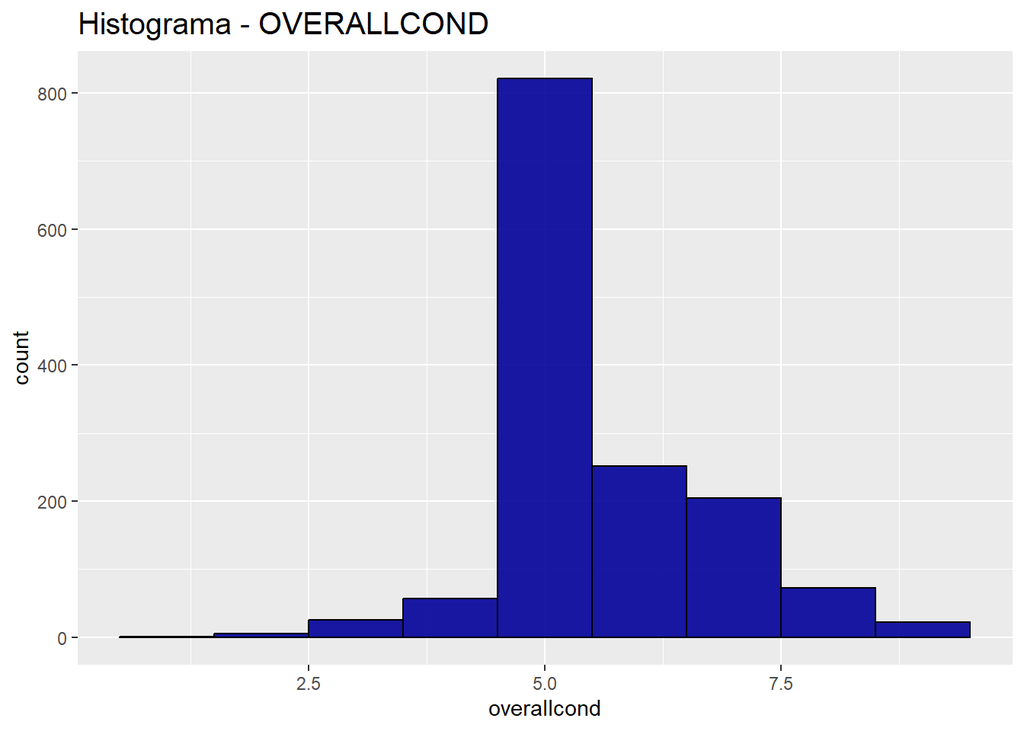

```r
p <- data %>%
  ggplot( aes(x=overallcond)) +
    geom_histogram( binwidth=1, fill="#000099", color="#000000", alpha=0.9) +
    ggtitle('Histograma - OVERALLCOND') +
    theme(
      plot.title = element_text(size=15)
    )
p
```

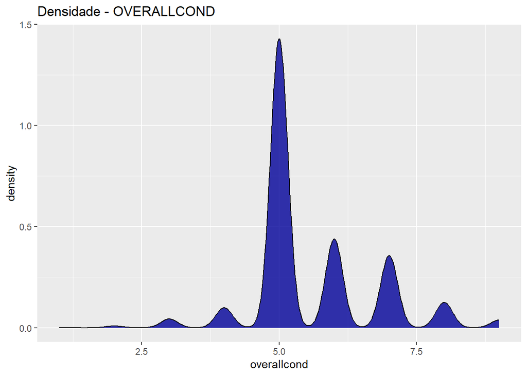

```r
data %>%
  ggplot( aes(x=overallcond)) +
    geom_density(fill="#000099", color="#000000", alpha=0.8) +
    ggtitle("Densidade - OVERALLCOND")
```

## YearBuilt(ano em que casa foi construída)

## A variável YearBuilt tem um compartamento diferente, pois ela aumenta sua frequência ao aumentar o ano. Além disso, os gráficos mostram uma tendência total para direita com um comportamento crescente, prova disso numéricamente são a média e a mediada (1971.268, 1973) em um intervalo de 1872 e 2010.

```r
cat("Média: ", mean(yearbuilt),"\n")
```

```
## Média:  1971.268
```

```r
cat("Mediana:",median(yearbuilt),"\n")
```

```
## Mediana: 1973
```

```r
cat("Intervalo:",max(yearbuilt) - min(yearbuilt),"\n")
```

```
## Intervalo: 138
```

```r
cat("Distancia Interquartilica:",IQR(yearbuilt),'\n')
```

```
## Distancia Interquartilica: 46
```

```r
cat('Variância:',var(yearbuilt),'\n')
```

```
## Variância: 912.2154
```

```r
cat('Desvio Padrão:',sd(yearbuilt),'\n')
```

```
## Desvio Padrão: 30.2029
```

```r
cat('\nTabela de Frequência')
```

```
##
## Tabela de Frequência
```

```r
table(yearbuilt)
```

```
## yearbuilt
## 1872 1875 1880 1882 1885 1890 1892 1893 1898 1900 1904 1905 1906 1908 1910 1911
##    1    1    4    1    2    2    2    1    1   10    1    1    1    2   17    1
## 1912 1913 1914 1915 1916 1917 1918 1919 1920 1921 1922 1923 1924 1925 1926 1927
##    3    1    7   10    8    1    7    3   30    6    8    7    7   16    9    3
## 1928 1929 1930 1931 1932 1934 1935 1936 1937 1938 1939 1940 1941 1942 1945 1946
##    7    4    9    6    4    3    6    9    5    4    8   18   15    2    6    7
## 1947 1948 1949 1950 1951 1952 1953 1954 1955 1956 1957 1958 1959 1960 1961 1962
##    5   14   12   20    6    5   12   24   16   14   20   24   26   17   14   19
## 1963 1964 1965 1966 1967 1968 1969 1970 1971 1972 1973 1974 1975 1976 1977 1978
##   16   15   24   18   16   22   14   24   22   23   11   10    8   33   32   16
## 1979 1980 1981 1982 1983 1984 1985 1986 1987 1988 1989 1990 1991 1992 1993 1994
##    9   10    5    6    4    9    5    5    3   11    3   12    5   13   17   19
## 1995 1996 1997 1998 1999 2000 2001 2002 2003 2004 2005 2006 2007 2008 2009 2010
##   18   15   14   25   25   24   20   23   45   54   64   67   49   23   18    1
```

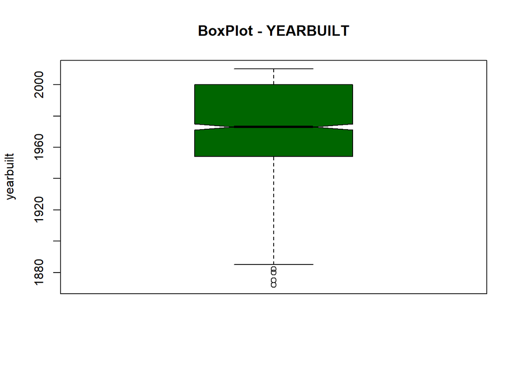

```r
boxplot(yearbuilt,
main = "BoxPlot - YEARBUILT",
ylab = "yearbuilt",
col = "#006600",
border = "black",
notch = TRUE
)
```

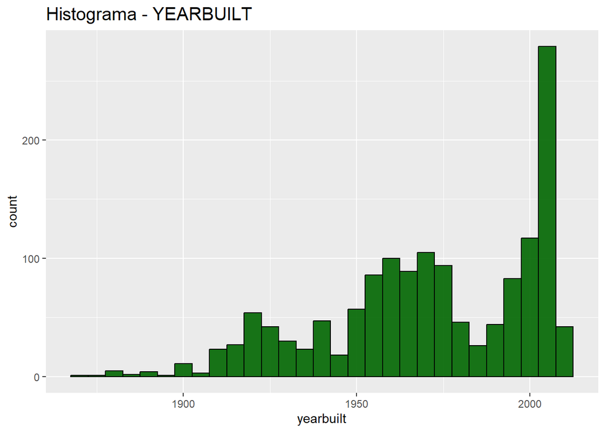

```r
p <- data %>%
  ggplot( aes(x=yearbuilt)) +
    geom_histogram( binwidth=5, fill="#006600", color="#000000", alpha=0.9) +
    ggtitle('Histograma - YEARBUILT') +
    theme(
      plot.title = element_text(size=15)
    )
p
```

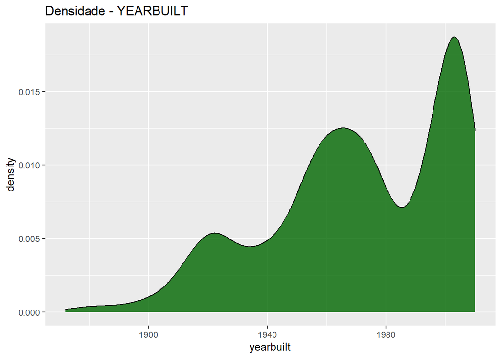

```r
data %>%
  ggplot( aes(x=yearbuilt)) +
    geom_density(fill="#006600", color="#000000", alpha=0.8) +
    ggtitle("Densidade - YEARBUILT")
```

## GarageCars(quantidades de carro que cabem na garagem da casa)

## A variável GarageCars segue um comportamento contrário às outras variáveis ao analisar os gráficos, visto que ela tem um tendência levemente para a esquerda, ou seja, há um frequência um pouco maior para garagens que cabem menos carros. Contudo, a mediana mostra que uma centralidade dos valores.

```r
cat("Média: ", mean(GarageCars),"\n")
```

```
## Média:  1.767123
```

```r
cat("Mediana:",median(GarageCars),"\n")
```

```
## Mediana: 2
```

```r
cat("Intervalo:",max(GarageCars) - min(GarageCars),"\n")
```

```
## Intervalo: 4
```

```r
cat("Distancia Interquartilica:",IQR(GarageCars),'\n')
```

```
## Distancia Interquartilica: 1
```

```r
cat('Variância:',var(GarageCars),'\n')
```

```
## Variância: 0.5584797
```

```r
cat('Desvio Padrão:',sd(GarageCars),'\n')
```

```
## Desvio Padrão: 0.747315
```

```r
cat('\nTabela de Frequência')
```

```
##
## Tabela de Frequência
```

```r
table(GarageCars)
```

```
## GarageCars
##   0   1   2   3   4
##  81 369 824 181   5
```

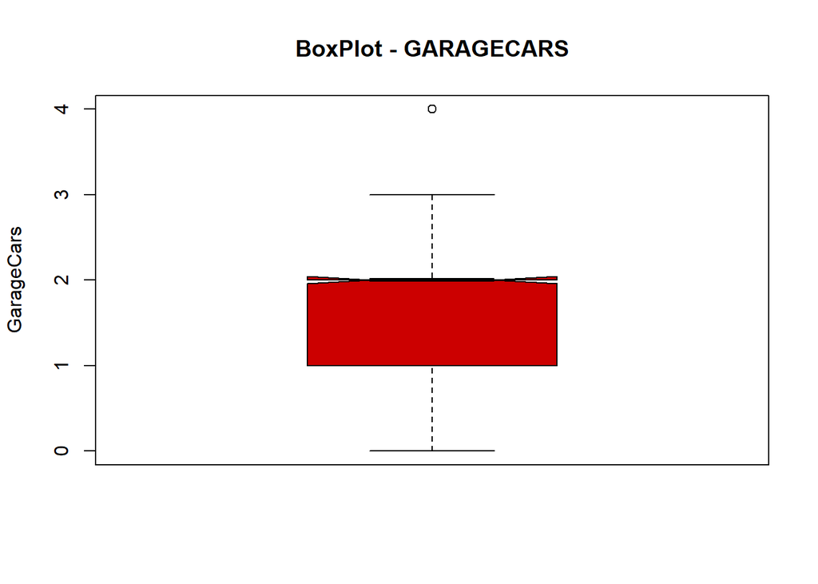

```r
boxplot(GarageCars,
main = "BoxPlot - GARAGECARS",
ylab = "GarageCars",
col = "#cc0000",
border = "black",
notch = TRUE
)
```

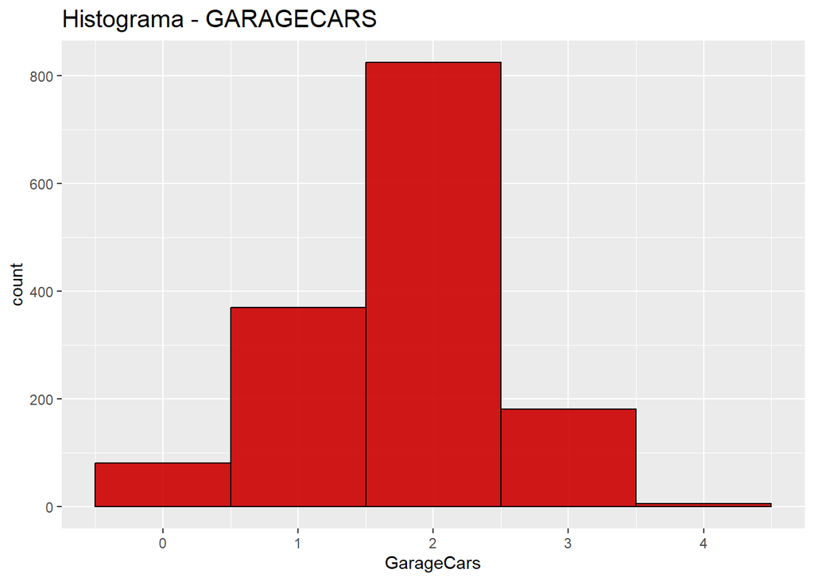

```r
p <- data %>%
  ggplot( aes(x=GarageCars)) +
    geom_histogram( binwidth=1, fill="#cc0000", color="#000000", alpha=0.9) +
    ggtitle('Histograma - GARAGECARS') +
    theme(
      plot.title = element_text(size=15)
    )
p
```

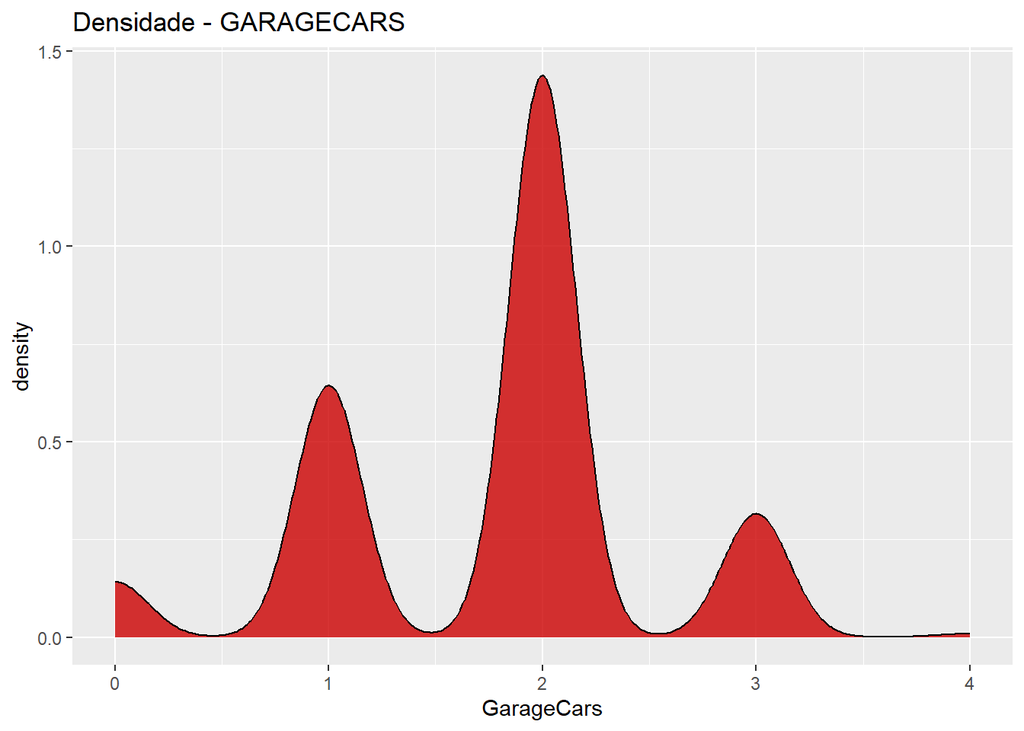

```r
data %>%
  ggplot( aes(x=GarageCars)) +
    geom_density(fill="#cc0000", color="#000000", alpha=0.8) +
    ggtitle("Densidade - GARAGECARS")
```

## SalePrice(Preço de venda)

## A variável SalePrice segue um comportamento parecido com a variável GarageCars ao analisar os gráficos, visto que ela tem um tendência fortemente para a esquerda, ou seja, há um frequência maior para a venda de casas com preços menores.

```r
cat("Média: ", mean(SalePrice),"\n")
```

```
## Média:  180921.2
```

```r
cat("Mediana:",median(SalePrice),"\n")
```

```
## Mediana: 163000
```

```r
cat("Intervalo:",max(SalePrice) - min(SalePrice),"\n")
```

```
## Intervalo: 720100
```

```r
cat("Distancia Interquartilica:",IQR(SalePrice),'\n')
```

```
## Distancia Interquartilica: 84025
```

```r
cat('Variância:',var(SalePrice),'\n')
```

```
## Variância: 6311111264
```

```r
cat('Desvio Padrão:',sd(SalePrice),'\n')
```

```
## Desvio Padrão: 79442.5
```

```r
cat('\nTabela de Frequência')
```

```
##
## Tabela de Frequência
```

```r
table(SalePrice)
```

```
## SalePrice
##  34900  35311  37900  39300  40000  52000  52500  55000  55993  58500  60000
##      1      1      1      1      1      1      1      2      1      1      3
##  61000  62383  64500  66500  67000  68400  68500  72500  73000  75000  75500
##      1      1      1      1      2      1      1      1      1      1      1
##  76000  76500  78000  79000  79500  79900  80000  80500  81000  82000  82500
##      1      1      1      3      1      2      4      1      3      3      3
##  83000  83500  84000  84500  84900  85000  85400  85500  86000  87000  87500
##      2      1      1      3      1      4      1      1      3      4      1
##  88000  89000  89471  89500  90000  90350  91000  91300  91500  92000  92900
##      4      1      1      2      3      1      3      1      2      1      1
##  93000  93500  94000  94500  94750  95000  96500  97000  97500  98000  98300
##      3      2      1      1      1      2      2      3      1      3      1
##  98600  99500  99900  1e+05 101000 101800 102000 102776 103000 103200 103600
##      1      1      1      9      1      1      3      1      1      1      1
```

[output cut: 108 more lines]

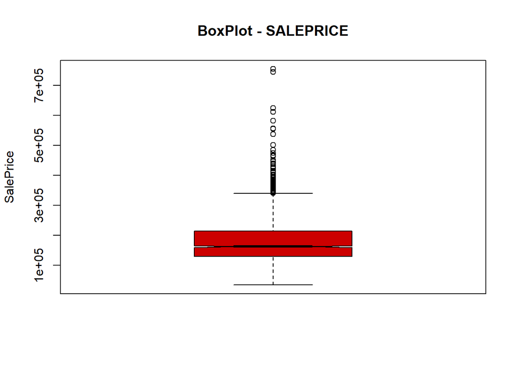

```r
boxplot(SalePrice,
main = "BoxPlot - SALEPRICE",
ylab = "SalePrice",
col = "#cc0000",
border = "black",
notch = TRUE
)
```

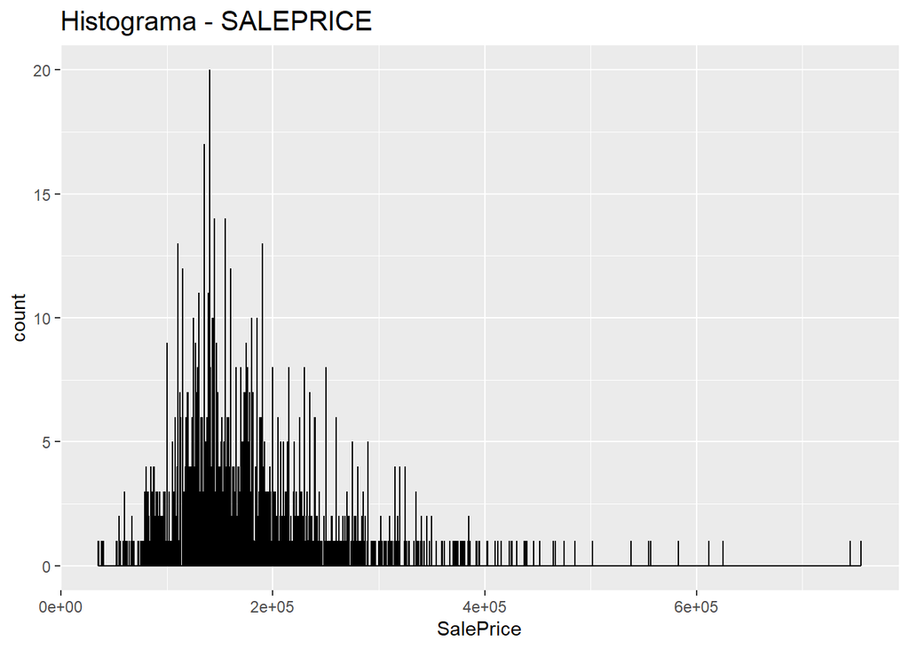

```r
p <- data %>%
  ggplot( aes(x=SalePrice)) +
    geom_histogram( binwidth=1, fill="#cc0000", color="#000000", alpha=0.9) +
    ggtitle('Histograma - SALEPRICE') +
    theme(
      plot.title = element_text(size=15)
    )
p
```

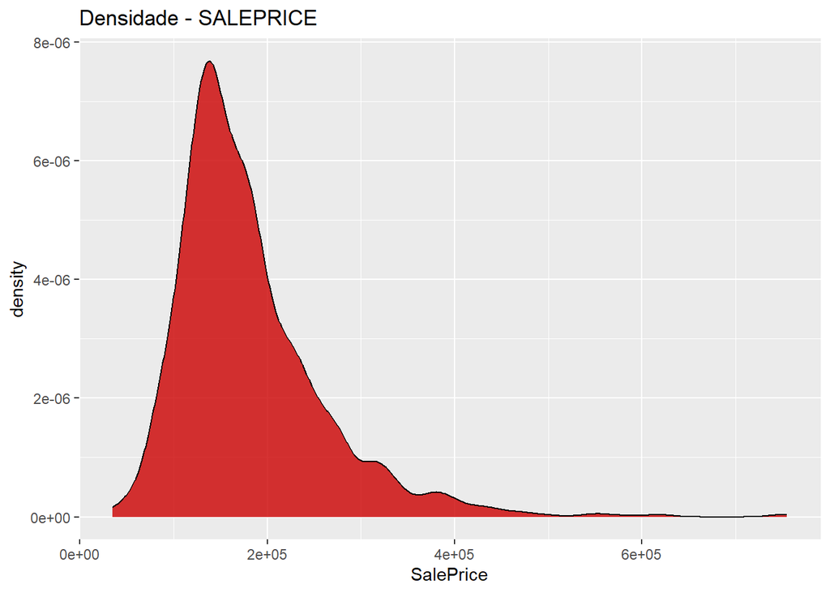

```r
data %>%
  ggplot( aes(x=SalePrice)) +
    geom_density(fill="#cc0000", color="#000000", alpha=0.8) +
    ggtitle("Densidade - SALEPRICE")
```

## As analises bivariadas foram feitas entre a variavel Saleprice e as demais variáveis. Calculamos a correlação e o gráfico de dispersão. As correlações mostram a relação entre duas variáveis se forem positiva possuem um comportamento crescente, se forem negativas possuem um comportamenteo descrescente e se for próximo de zero possuem um comportamento constante. Os gráficos de dispersão relacionam as duas variáveis em um plano cartersiano (demais variáveis,SalePrice).

## A Correlação entre OveralQual e SalePrice é positiva e próxima de 1 , isto quer dizer que possui um comportamento crescente forte. Prova disso visualmente, é o gráfico de dispersão entre as duas variáveis que é crescente. Ademais, isso quer dizer que quanto melhor o indice de qualidade do imóvel maior é seu valor de venda.

```r
cat("Correlação OverallQual: ", cor(data$OverallQual,data$SalePrice),"\n")
```

```
## Correlação OverallQual:  0.7909816
```

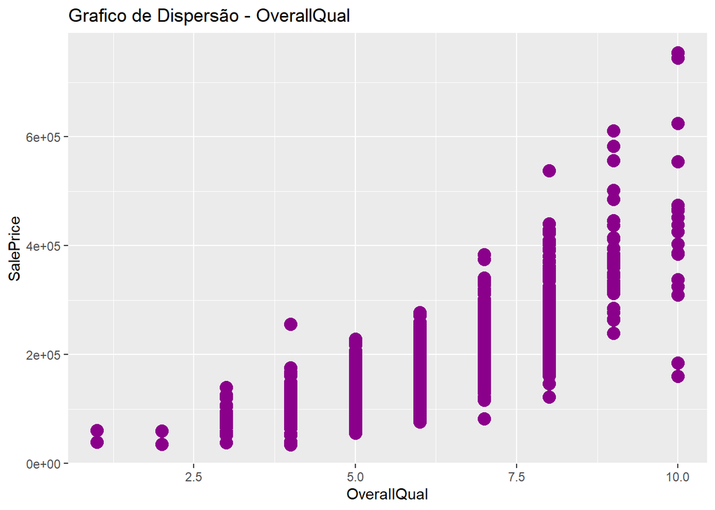

```r
ggplot(data, aes(x= OverallQual, y=SalePrice)) +
  ggtitle("Grafico de Dispersão - OverallQual") +
  geom_point(size=4, color="#8b008b")
```

## A Correlação entre OverallCond e SalePrice é -0.077 quer dizer que é próxima de zero, ou seja, o comportamento é constante. Prova disso visualmente, é o gráfico de dispersão entre as duas variáveis é relativamente constante, porém há um leve decremento a partir do meio do gráfico (por isso é negativo). Ademais, isso mostra que o Índice da condição de estado do imóvel é relativamente constante ao valor de venda.

```r
cat("Correlação OverallCond: ", cor(data$OverallCond,data$SalePrice),"\n")
```

```
## Correlação OverallCond:  -0.07785589
```

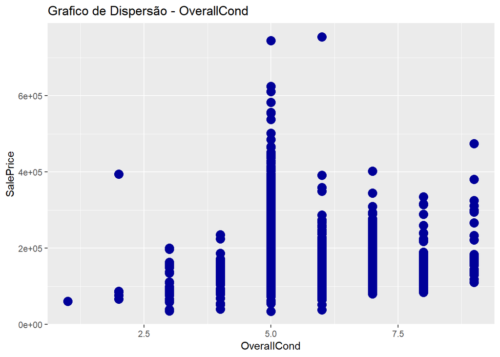

```r
ggplot(data, aes(x= OverallCond, y=SalePrice)) +
  ggtitle("Grafico de Dispersão - OverallCond") +
  geom_point(size=4, color="#000099")
```

## A Correlação entre YearBuilt e SalePrice é de 0.523, isto quer dizer que é crescente e mais próxima de 1, ou seja, é um leve comportamento crescente. Prova disso visualmente, é o gráfico de dispersão entre as duas variáveis que é levemente crescente. Ademais, isso quer dizer que quanto mais nova a casa maior seu valor, mas é uma proporção relativamente pequena.

```r
cat("Correlação YearBuilt: ", cor(data$YearBuilt,data$SalePrice),"\n")
```

```
## Correlação YearBuilt:  0.5228973
```

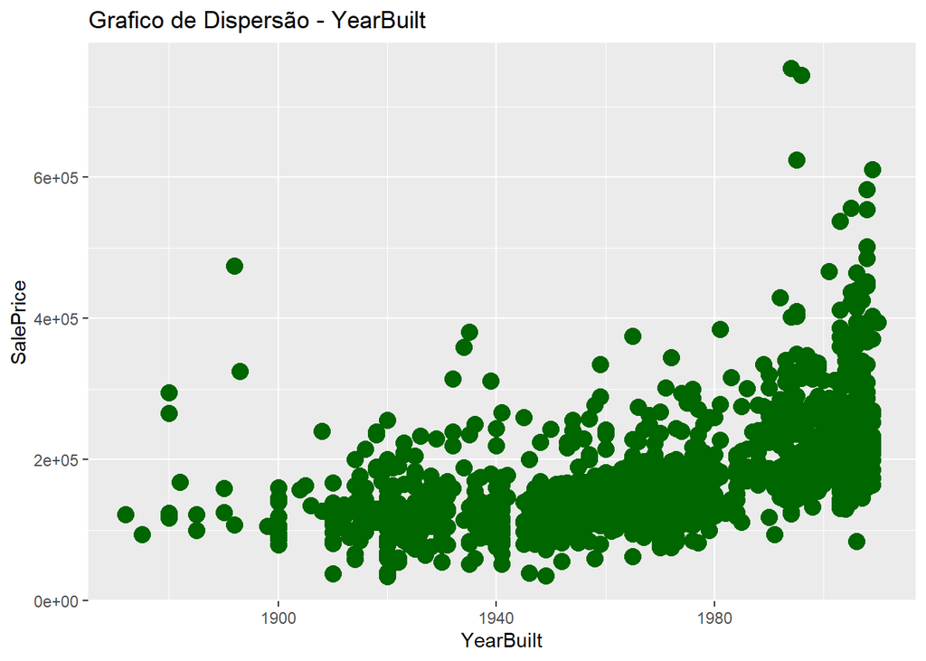

```r
ggplot(data, aes(x= YearBuilt, y=SalePrice)) +
  ggtitle("Grafico de Dispersão - YearBuilt") +
  geom_point(size=4, color="#006600")
```

## A Correlação entre GarageCars e SalePrice é 0.64, isto quer dizer que a relação possui um comportamento crescente. Prova disso visualmente, é o gráfico de dispersão entre as duas variáveis que é crescente. Ademais, isso quer dizer que quanto mais carro que couber na garage maior é o valor do imóvel.

```r
cat("Correlação GarageCars: ", cor(data$GarageCars,data$SalePrice),"\n")
```

```
## Correlação GarageCars:  0.6404092
```

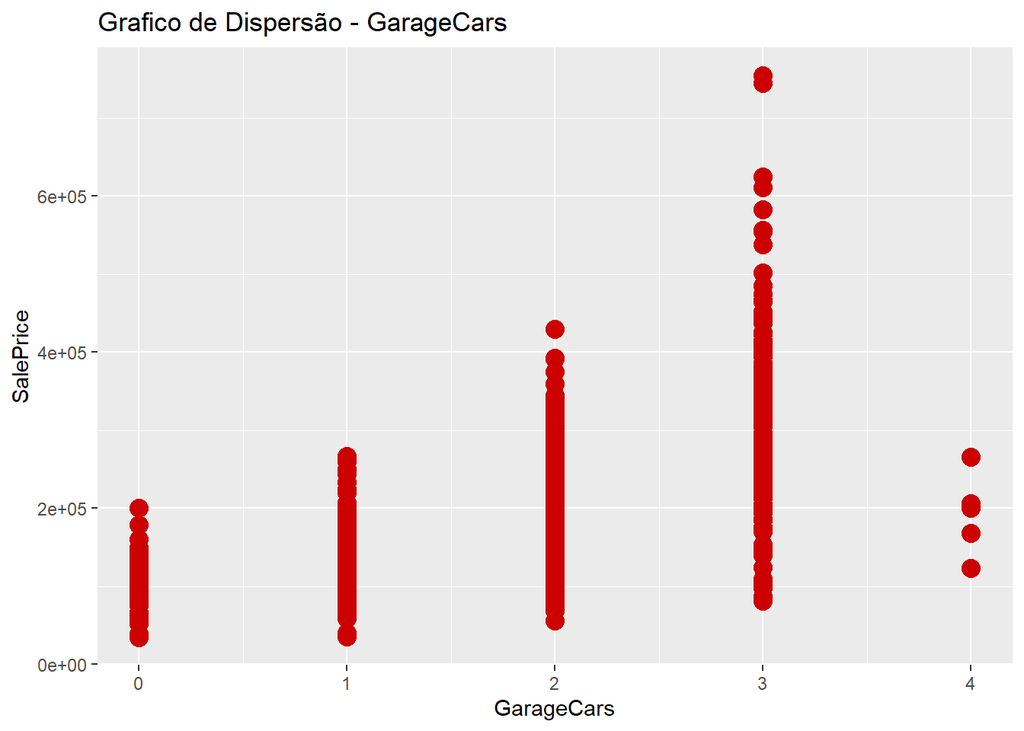

```r
ggplot(data, aes(x= GarageCars, y=SalePrice)) +
  ggtitle("Grafico de Dispersão - GarageCars") +
  geom_point(size=4, color="#cc0000")
```

## REGRESSÕES LINEARES com as analises de resíduos.

## Regressão Linear para OverellQual sem ajustes.

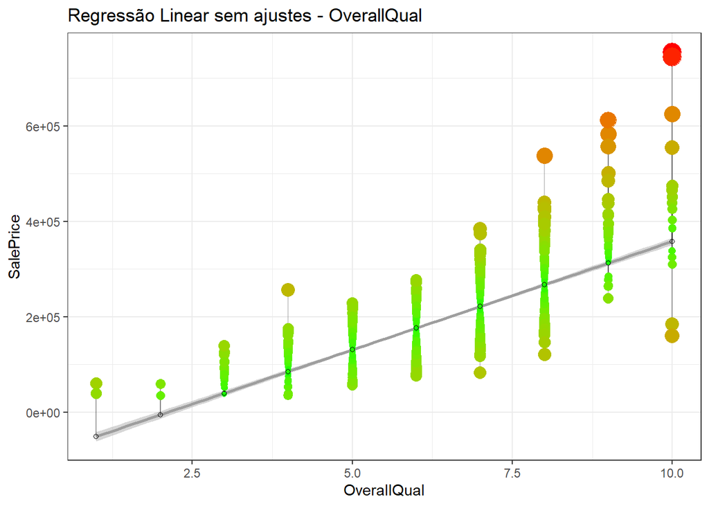

```r
fit1 <- lm(SalePrice ~ OverallQual, data = data)
data$predicted <- predict(fit1)
data$residuals <- residuals(fit1)
ggplot(data, aes(x = OverallQual, y = SalePrice)) +
geom_smooth(formula = y ~ x, method = "lm", se = TRUE, color = "8b008b") +
  geom_segment(aes(xend = OverallQual, yend = predicted), alpha = .2) +
  geom_point(aes(color = abs(residuals), size = abs(residuals))) +
  scale_color_continuous(low = "green", high = "red") +
  guides(color = FALSE, size = FALSE) +
  geom_point(aes(y = predicted), shape = 1) +
  ggtitle("Regressão Linear sem ajustes - OverallQual")+
  theme_bw()
```

## Ao analisar a normalidade dos resíduos com o shapiro.test() verificamos que o p-value é muito próximo de zero o que quer dizer que eles não seguem uma normalidade e que os intervalos de confiança estão comprometidos.

```r
shapiro.test(residuals(fit1))
```

```
##
##  Shapiro-Wilk normality test
##
## data:  residuals(fit1)
## W = 0.90582, p-value < 2.2e-16
```

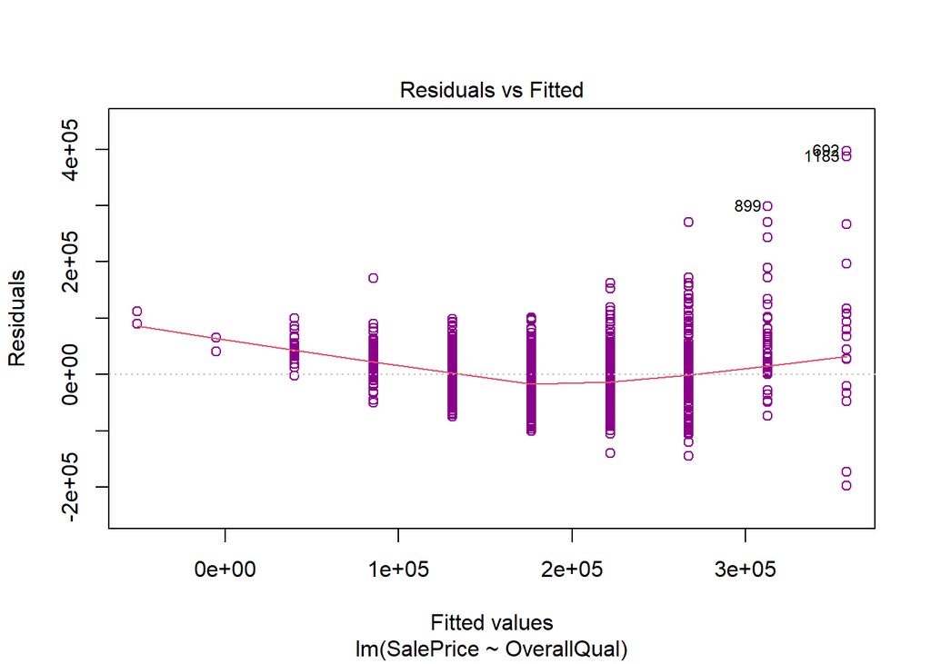

```r
plot(fit1,which = 1,col=c("#8b008b"))
```

## Para tentar chegar em uma normalidade aplicamos um log na variável SalePrice.

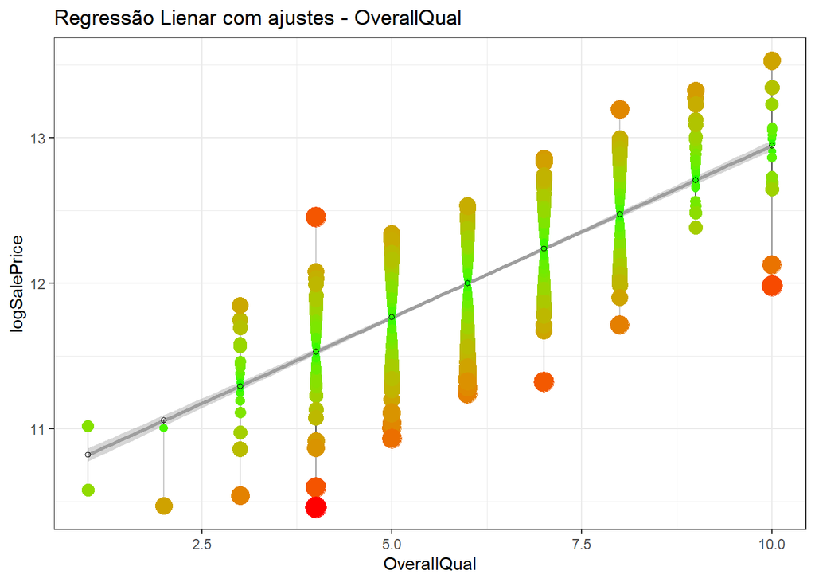

```r
logSalePrice <- log(data$SalePrice)
fit <- lm(logSalePrice ~ OverallQual, data = data)
data$predicted <- predict(fit)
data$residuals <- residuals(fit)
ggplot(data, aes(x = OverallQual, y = logSalePrice)) +
geom_smooth(formula = y ~ x, method = "lm", se = TRUE, color = "8b008b") +
  geom_segment(aes(xend = OverallQual, yend = predicted), alpha = .2) +
  geom_point(aes(color = abs(residuals), size = abs(residuals))) +
  scale_color_continuous(low = "green", high = "red") +
  guides(color = FALSE, size = FALSE) +
  geom_point(aes(y = predicted), shape = 1) +
  ggtitle("Regressão Lienar com ajustes - OverallQual")+
  theme_bw()
```

## Verificamos o p-value. Contudo, ainda encontramos um valor muito próximo de zero que faz com que não cheguemos em uma normalidade.

```r
shapiro.test(residuals(fit))
```

```
##
##  Shapiro-Wilk normality test
##
## data:  residuals(fit)
## W = 0.98216, p-value = 1.811e-12
```

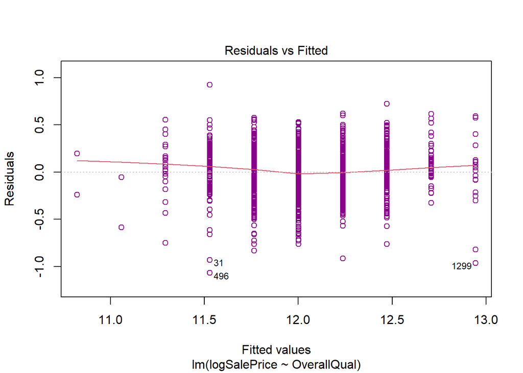

```r
plot(fit,which = 1,col=c("#8b008b"))
```

## Fizemos o mesmo processo da variavel OverallQual nas demais variáveis para tentar atingir a normalidade.

## Regressão Linear para OverellCond sem ajustes.

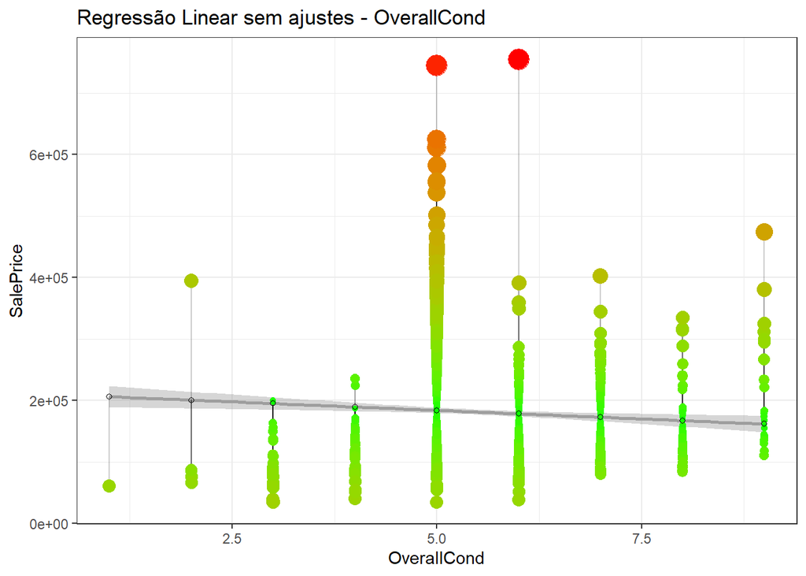

```r
fit2 <- lm(SalePrice ~ OverallCond, data = data)
data$predicted <- predict(fit2)
data$residuals <- residuals(fit2)
ggplot(data, aes(x = OverallCond, y = SalePrice)) +
geom_smooth(formula = y ~ x, method = "lm", se = TRUE, color = "8b008b") +
  geom_segment(aes(xend = OverallCond, yend = predicted), alpha = .2) +
  geom_point(aes(color = abs(residuals), size = abs(residuals))) +
  scale_color_continuous(low = "green", high = "red") +
  guides(color = FALSE, size = FALSE) +
  geom_point(aes(y = predicted), shape = 1) +
  ggtitle("Regressão Linear sem ajustes - OverallCond")+
  theme_bw()
```

## Ao analisar a normalidade dos resíduos com o shapiro.test() verificamos que o p-value é muito próximo de zero o que quer dizer que eles não seguem uma normalidade e que os intervalos de confiança estão comprometidos.

```r
shapiro.test(residuals(fit2))
```

```
##
##  Shapiro-Wilk normality test
##
## data:  residuals(fit2)
## W = 0.87642, p-value < 2.2e-16
```

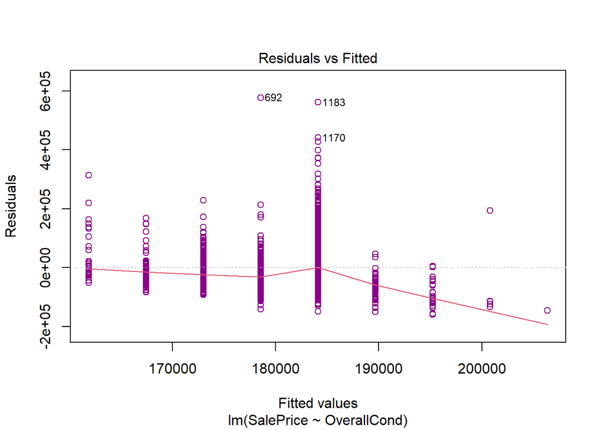

```r
plot(fit2,which = 1,col=c("#8b008b"))
```

## Para tentar chegar em uma normalidade aplicamos um log na variável SalePrice.

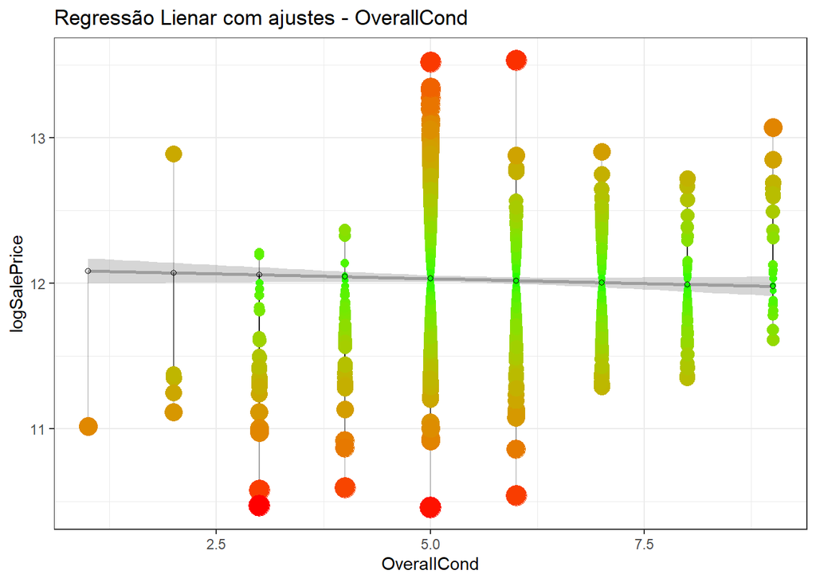

```r
logSalePrice <- log(data$SalePrice)
fit <- lm(logSalePrice ~ OverallCond, data = data)
data$predicted <- predict(fit)
data$residuals <- residuals(fit)
ggplot(data, aes(x = OverallCond, y = logSalePrice)) +
geom_smooth(formula = y ~ x, method = "lm", se = TRUE, color = "8b008b") +
  geom_segment(aes(xend = OverallCond, yend = predicted), alpha = .2) +
  geom_point(aes(color = abs(residuals), size = abs(residuals))) +
  scale_color_continuous(low = "green", high = "red") +
  guides(color = FALSE, size = FALSE) +
  geom_point(aes(y = predicted), shape = 1) +
  ggtitle("Regressão Lienar com ajustes - OverallCond")+
  theme_bw()
```

## Verificamos o p-value. Contudo, ainda encontramos um valor muito próximo de zero que faz com que não cheguemos em uma normalidade.

```r
shapiro.test(residuals(fit))
```

```
##
##  Shapiro-Wilk normality test
##
## data:  residuals(fit)
## W = 0.99083, p-value = 6.503e-08
```

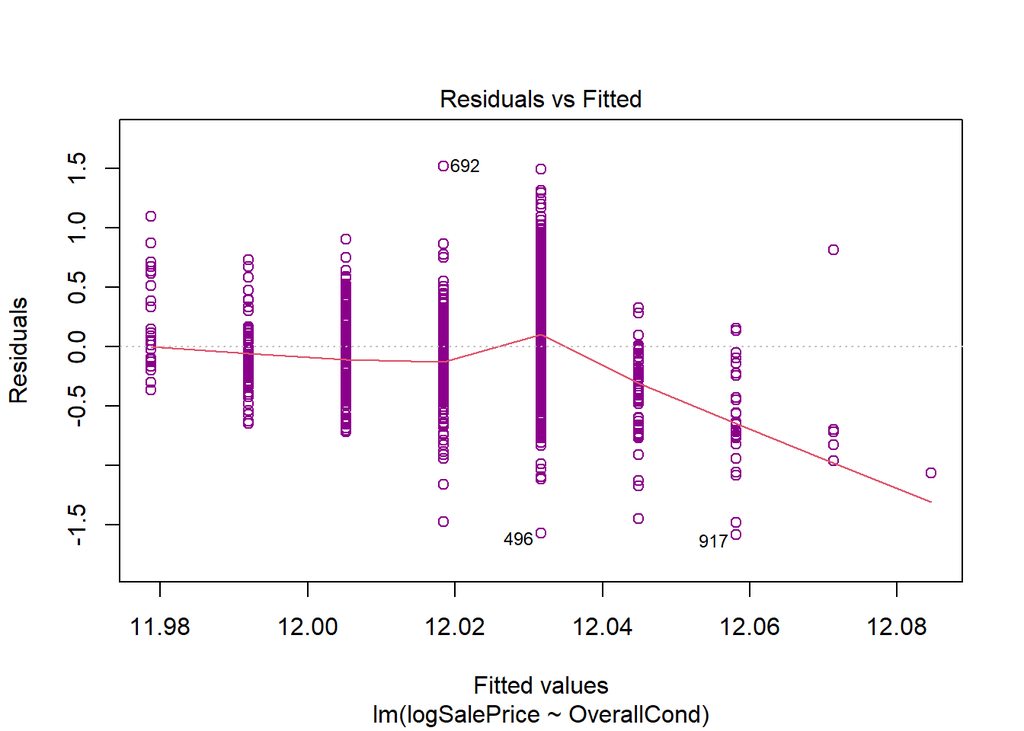

```r
plot(fit,which = 1,col=c("#8b008b"))
```

## Regressão Linear para YearBuilt sem ajustes.

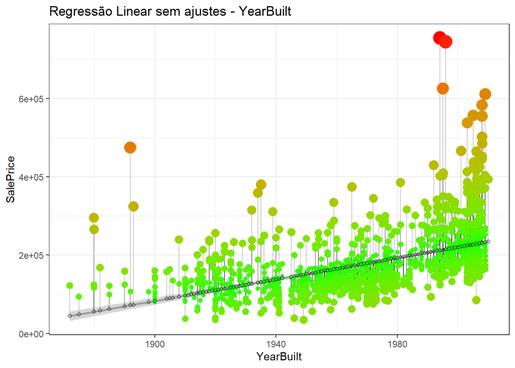

```r
fit3 <- lm(SalePrice ~ YearBuilt, data = data)
data$predicted <- predict(fit3)
data$residuals <- residuals(fit3)
ggplot(data, aes(x = YearBuilt, y = SalePrice)) +
geom_smooth(formula = y ~ x, method = "lm", se = TRUE, color = "8b008b") +
  geom_segment(aes(xend = YearBuilt, yend = predicted), alpha = .2) +
  geom_point(aes(color = abs(residuals), size = abs(residuals))) +
  scale_color_continuous(low = "green", high = "red") +
  guides(color = FALSE, size = FALSE) +
  geom_point(aes(y = predicted), shape = 1) +
  ggtitle("Regressão Linear sem ajustes - YearBuilt")+
  theme_bw()
```

## Ao analisar a normalidade dos resíduos com o shapiro.test() verificamos que o p-value é muito próximo de zero o que quer dizer que eles não seguem uma normalidade e que os intervalos de confiança estão comprometidos.

```r
shapiro.test(residuals(fit3))
```

```
##
##  Shapiro-Wilk normality test
##
## data:  residuals(fit3)
## W = 0.83785, p-value < 2.2e-16
```

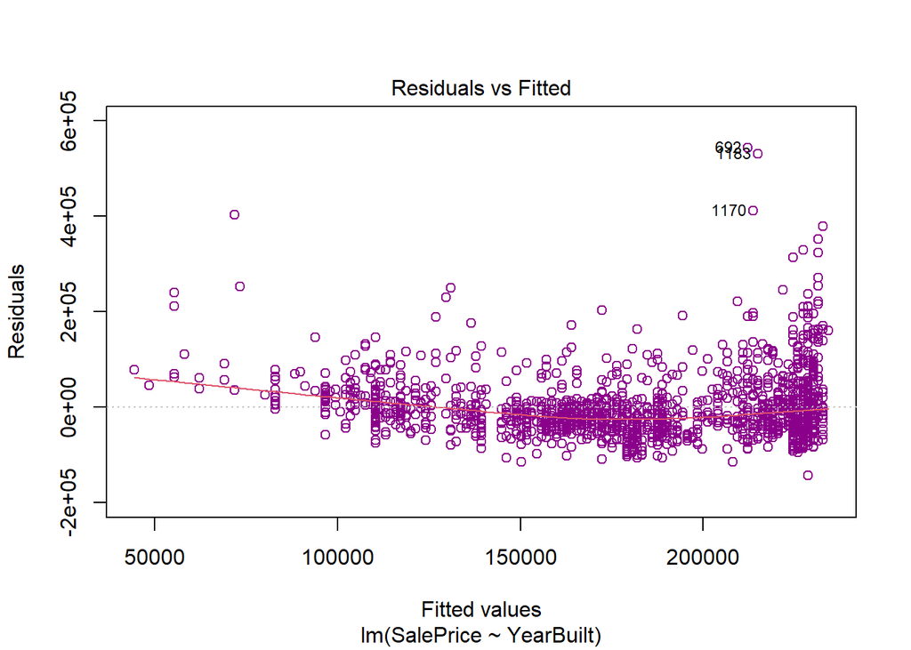

```r
plot(fit3,which = 1,col=c("#8b008b"))
```

## Para tentar chegar em uma normalidade aplicamos um log na variável SalePrice.

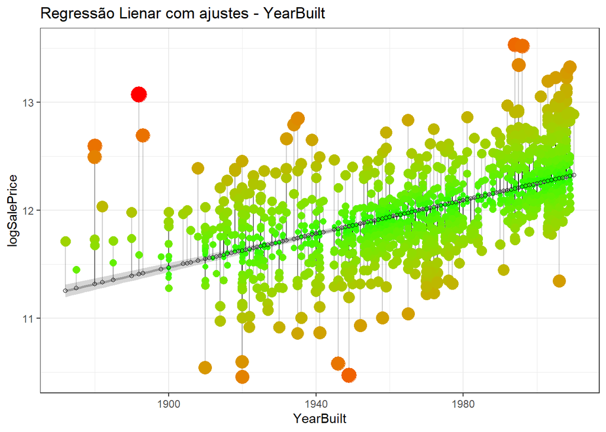

```r
logSalePrice <- log(data$SalePrice)
fit <- lm(logSalePrice ~ YearBuilt, data = data)
data$predicted <- predict(fit)
data$residuals <- residuals(fit)
ggplot(data, aes(x = YearBuilt, y = logSalePrice)) +
geom_smooth(formula = y ~ x, method = "lm", se = TRUE, color = "8b008b") +
  geom_segment(aes(xend = YearBuilt, yend = predicted), alpha = .2) +
  geom_point(aes(color = abs(residuals), size = abs(residuals))) +
  scale_color_continuous(low = "green", high = "red") +
  guides(color = FALSE, size = FALSE) +
  geom_point(aes(y = predicted), shape = 1) +
  ggtitle("Regressão Lienar com ajustes - YearBuilt")+
  theme_bw()
```

## Verificamos o p-value. Contudo, ainda encontramos um valor muito próximo de zero que faz com que não cheguemos em uma normalidade.

```r
shapiro.test(residuals(fit))
```

```
##
##  Shapiro-Wilk normality test
##
## data:  residuals(fit)
## W = 0.97436, p-value = 1.862e-15
```

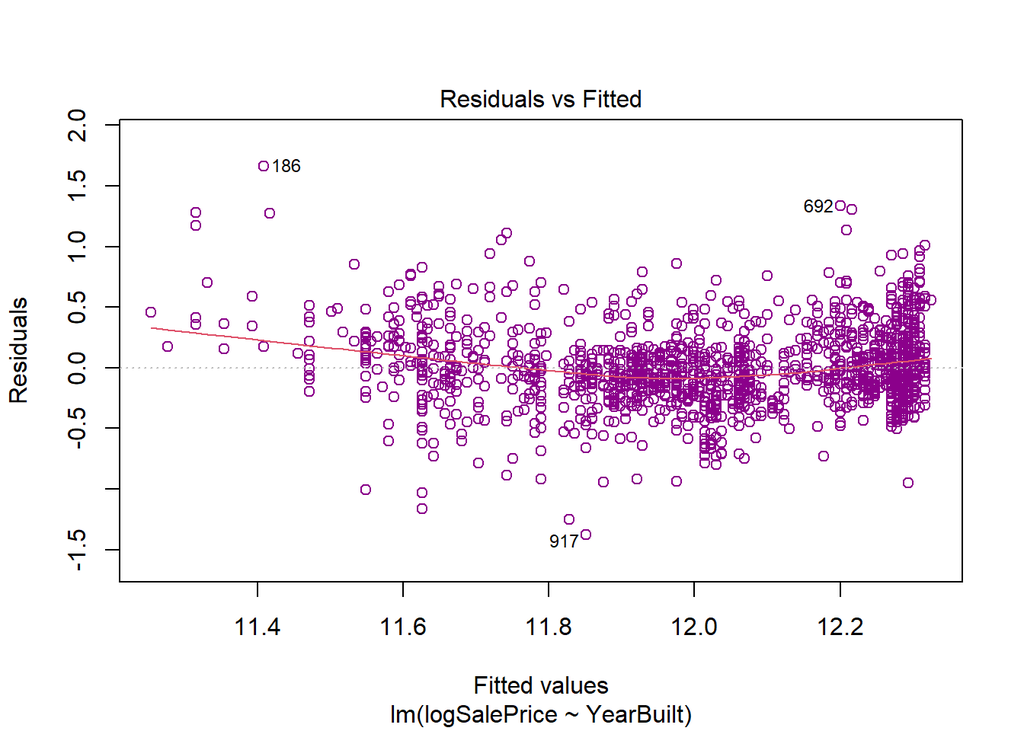

```r
plot(fit,which = 1,col=c("#8b008b"))
```

## Regressão Linear para GarageCars sem ajustes.

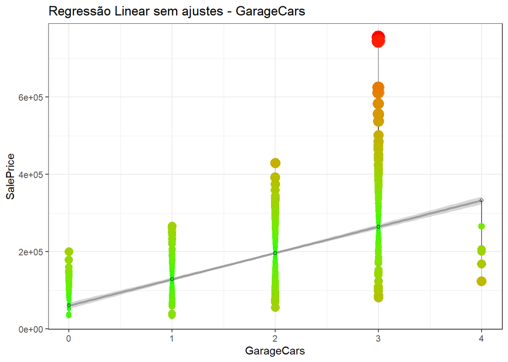

```r
fit4 <- lm(SalePrice ~ GarageCars, data = data)
data$predicted <- predict(fit4)
data$residuals <- residuals(fit4)
ggplot(data, aes(x = GarageCars, y = SalePrice)) +
geom_smooth(formula = y ~ x, method = "lm", se = TRUE, color = "8b008b") +
  geom_segment(aes(xend = GarageCars, yend = predicted), alpha = .2) +
  geom_point(aes(color = abs(residuals), size = abs(residuals))) +
  scale_color_continuous(low = "green", high = "red") +
  guides(color = FALSE, size = FALSE) +
  geom_point(aes(y = predicted), shape = 1) +
  ggtitle("Regressão Linear sem ajustes - GarageCars")+
  theme_bw()
```

## Ao analisar a normalidade dos resíduos com o shapiro.test() verificamos que o p-value é muito próximo de zero o que quer dizer que eles não seguem uma normalidade e que os intervalos de confiança estão comprometidos.

```r
shapiro.test(residuals(fit4))
```

```
##
##  Shapiro-Wilk normality test
##
## data:  residuals(fit4)
## W = 0.90407, p-value < 2.2e-16
```

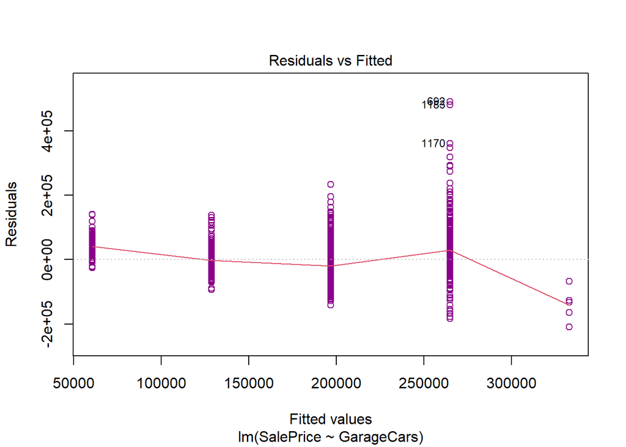

```r
plot(fit4,which = 1,col=c("#8b008b"))
```

## Para tentar chegar em uma normalidade aplicamos um log na variável SalePrice.

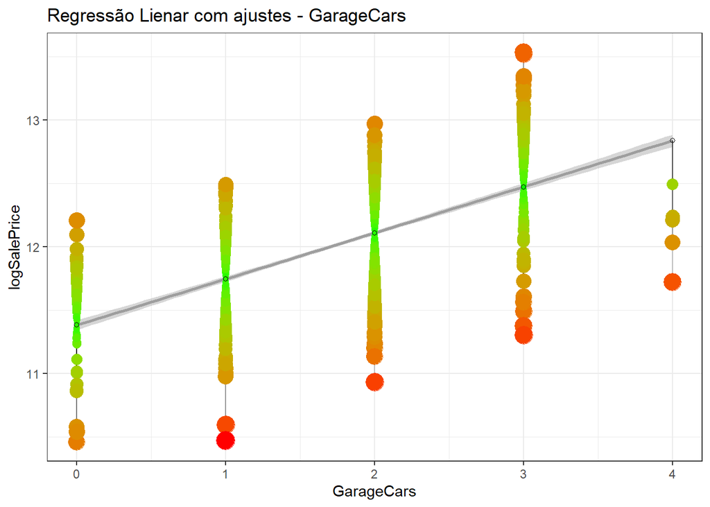

```r
logSalePrice <- log(data$SalePrice)
fit <- lm(logSalePrice ~ GarageCars, data = data)
data$predicted <- predict(fit)
data$residuals <- residuals(fit)
ggplot(data, aes(x = GarageCars, y = logSalePrice)) +
geom_smooth(formula = y ~ x, method = "lm", se = TRUE, color = "8b008b") +
  geom_segment(aes(xend = GarageCars, yend = predicted), alpha = .2) +
  geom_point(aes(color = abs(residuals), size = abs(residuals))) +
  scale_color_continuous(low = "green", high = "red") +
  guides(color = FALSE, size = FALSE) +
  geom_point(aes(y = predicted), shape = 1) +
  ggtitle("Regressão Lienar com ajustes - GarageCars")+
  theme_bw()
```

## Verificamos o p-value. Contudo, ainda encontramos um valor muito próximo de zero que faz com que não cheguemos em uma normalidade.

```r
shapiro.test(residuals(fit))
```

```
##
##  Shapiro-Wilk normality test
##
## data:  residuals(fit)
## W = 0.98394, p-value = 1.132e-11
```

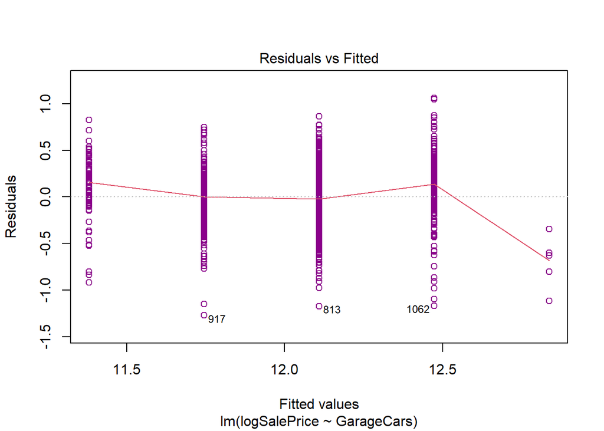

```r
plot(fit,which = 1,col=c("#8b008b"))
```

## Sendo assim, verificamos que não conseguimos definir uma regressão linear bem ajustada, visto que usamos o modelo simples. Contudo, mesmo assim iremos calcular os intervalos e confiança.

## Intervalos de Confiança para a Variável OverllQual utilizando a função confint().

```r
confint(fit1)
```

```
##                  2.5 %    97.5 %
## (Intercept) -107497.80 -84914.35
## OverallQual   43630.29  47241.31
```

## Intervalos de Confiança para a Variável OverllCond utilizando a função confint().

```r
confint(fit2)
```

```
##                  2.5 %     97.5 %
## (Intercept) 191122.470 232696.715
## OverallCond  -9214.449  -1901.782
```

## Intervalos de Confiança para a Variável YearBuilt utilizando a função confint().

```r
confint(fit3)
```

```
##                    2.5 %       97.5 %
## (Intercept) -2757384.656 -2303231.836
## YearBuilt       1260.194     1490.553
```

## Intervalos de Confiança para a Variável GarageCars utilizando a função confint().

```r
confint(fit4)
```

```
##                2.5 %   97.5 %
## (Intercept) 52572.02 68665.94
## GarageCars  63883.70 72272.30
```

## Concluimos que conseguimos determinar algumas relações e informações acerca da leitura e interpretação dos dados, algumas dela: ‘conforme a qualidade do imóvel aumenta o seu preço de venda aumentará também’, ‘quanto mais carros couber na garagem do imóvel maior será o preço de venda’, frequências etc. Ademais, a normalidade dos resíduos não foi suficiente para gerar um intervalo de confiança para o coeficiente da angular da regressão linear mesmo realizando alguns ajustes, visto que foi feita uma regressão linear simples.

## As referências necessárias para a realização desse trabalho estão abaixo em forma de links. Agradecemos a todos os autores pelo conhecimento compartilhado.

## - Prof. Afrânio Vieira por todas as aulas

## - https://r-graph-gallery.com/index.html (Gráficos)

## - https://www.statology.org/univariate-analysis-in-r/

## - https://www.statology.org/bivariate-analysis-in-r/

## - https://rpubs.com/iabrady/residual-analysis

## - https://www.rdocumentation.org/packages/stats/versions/3.6.2/topics/shapiro.test

## - https://cran.r-project.org/web/packages/olsrr/vignettes/residual_diagnostics.html